# Cvicenie 11.15 - Bayesianska Regresia pre Perth Weather

Dana

2025-11-26

# Zadanie

**Exercise 11.15 (Open-ended)**: Pouzite data `weather_perth` z balicka `bayesrules` na vytvorenie “uspesneho” modelu poobednajsich teplot (`temp3pm`) v Perth, Australia. Mozete si vybrat, ktore prediktory pouzijete a ci zahrnute interakcne cleny. Nezabudnite vyhodnotit vas model a vysvetlit proces modelovania.

# Teoreticky Uvod

## Bayesianska Normalna Regresia

Pre kvantitativnu odpoved $Y$ a prediktory $(X_1, X_2, \ldots, X_p)$:

$$\begin{aligned}
Y_i | \beta_0, \beta_1, \ldots, \beta_p, \sigma
&\stackrel{ind}{\sim} N(\mu_i, \sigma^2) \\
\mu_i &= \beta_0 + \beta_1 X_{i1} + \beta_2 X_{i2} + \cdots +
\beta_p X_{ip}
\end{aligned}$$

## Model s Kategorickym Prediktorom

Pre kategoricky prediktor $X_2$ (napr. `raintoday` s hodnotami 0/1):

$$X_{i2} = \begin{cases}
1 & \text{ak prsi (Yes)} \\
0 & \text{inak (No - referencna kategoria)}
\end{cases}$$

Potom koeficient $\beta_2$ reprezentuje typicky rozdiel v $Y$ medzi danou kategoriou a referencnou kategoriou.

## Model s Interakciou

Ked prediktory $X_1$ a $X_2$ interaguju, vztah medzi $Y$ a $X_1$ sa meni v zavislosti od hodnoty $X_2$:

$$\mu_i = \beta_0 + \beta_1 X_{i1} + \beta_2 X_{i2} + \beta_3 X_{i1}
X_{i2}$$

Pre nas model s `temp9am` ($X_1$) a `raintoday` ($X_2$):

- **Ked neprsi** ($X_2 = 0$): $\mu = \beta_0 + \beta_1 \cdot \text{temp9am}$
- **Ked prsi** ($X_2 = 1$): $\mu = (\beta_0 + \beta_2) + (\beta_1 + \beta_3) \cdot \text{temp9am}$

Koeficient interakcie $\beta_3$ teda vyjadruje, o kolko sa meni sklon (slope) vztahu medzi teplotami v zavislosti od toho, ci prsi.

# Nacitanie Balickov a Dat

```r
# Nacitanie balickov
library(bayesrules)
library(rstanarm)
library(bayesplot)
library(tidyverse)
library(broom.mixed)
library(tidybayes)
library(janitor)

# Nacitanie dat
data(weather_perth)
```

# Prieskumna Vizualizacia

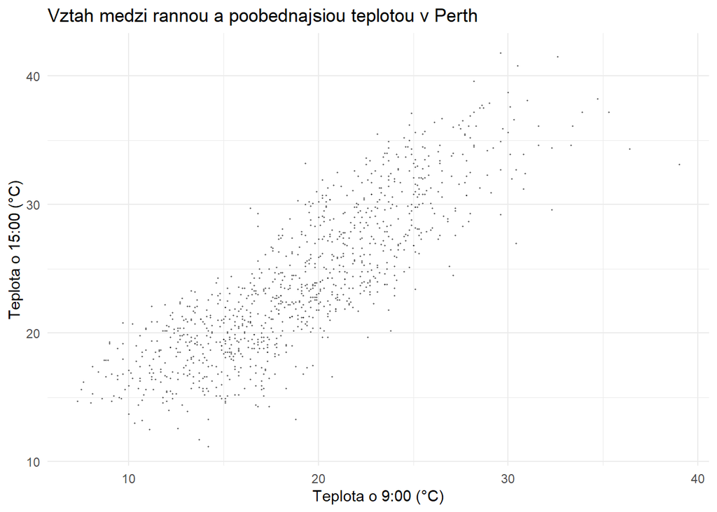

```r
ggplot(weather_perth, aes(x = temp9am, y = temp3pm)) +
  geom_point(size = 0.2, alpha = 0.5) +
  labs(title = "Vztah medzi rannou a poobednajsiou teplotou v Perth",
       x = "Teplota o 9:00 (°C)",
       y = "Teplota o 15:00 (°C)") +
  theme_minimal()
```

# Model 1: Jednoduchy Model

## Specifikacia Modelu 1

$$\begin{aligned}
Y_i | \beta_0, \beta_1, \sigma &\stackrel{ind}{\sim} N(\mu_i,
\sigma^2) \\
\mu_i &= \beta_0 + \beta_1 \cdot \text{temp9am}_i
\end{aligned}$$

**Priory:**

$$\begin{aligned}
\beta_{0c} &\sim N(25, 5^2) \\
\beta_1 &\sim N(0, 2.5^2) \quad \text{(autoscaled)} \\
\sigma &\sim \text{Exp}(1) \quad \text{(autoscaled)}
\end{aligned}$$

## Simulacia Posterioru

```r
weather_model_1 <- stan_glm(
  temp3pm ~ temp9am,
  data = weather_perth, family = gaussian,
  prior_intercept = normal(25, 5),
  prior = normal(0, 2.5, autoscale = TRUE),
  prior_aux = exponential(1, autoscale = TRUE),
  chains = 4, iter = 5000*2, seed = 84735,
  refresh = 0)
```

## Prior Specifikacia

```r
prior_summary(weather_model_1)
```

```
## Priors for model 'weather_model_1'
## ------
## Intercept (after predictors centered)
##  ~ normal(location = 25, scale = 5)
##
## Coefficients
##   Specified prior:
##     ~ normal(location = 0, scale = 2.5)
##   Adjusted prior:
##     ~ normal(location = 0, scale = 2.8)
##
## Auxiliary (sigma)
##   Specified prior:
##     ~ exponential(rate = 1)
##   Adjusted prior:
##     ~ exponential(rate = 0.17)
## ------
## See help('prior_summary.stanreg') for more details
```

## MCMC Diagnostika

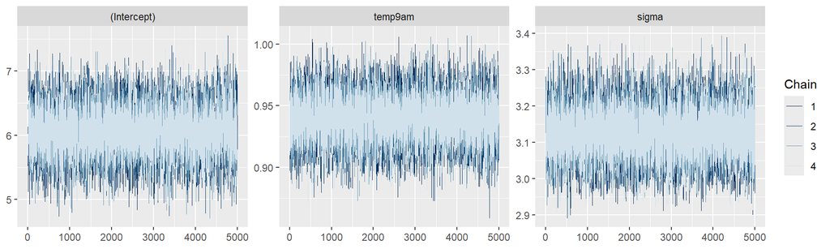

```r
mcmc_trace(weather_model_1, size = 0.1)
```

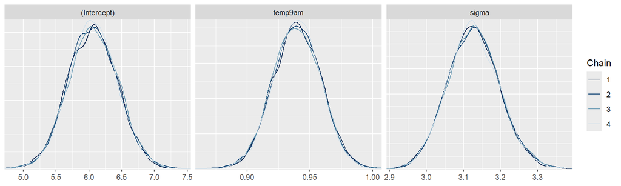

```r
mcmc_dens_overlay(weather_model_1)
```

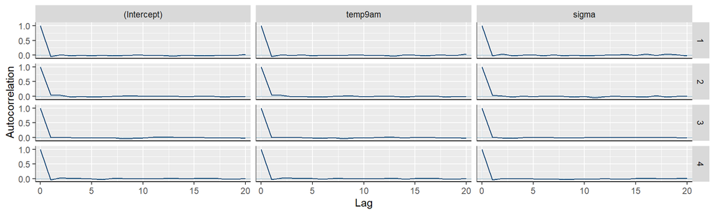

```r
mcmc_acf(weather_model_1)
```

```r
cat("Effective Sample Size Ratios:\n")
```

```
## Effective Sample Size Ratios:
```

```r
neff_ratio(weather_model_1)
```

```
## (Intercept)     temp9am       sigma
##     0.98315     0.96920     1.00065
```

```r
cat("\nR-hat hodnoty:\n")
```

```
##
## R-hat hodnoty:
```

```r
rhat(weather_model_1)
```

```
## (Intercept)     temp9am       sigma
##   1.0000184   0.9999971   1.0000390
```

## Posterior Credible Intervals

```r
posterior_interval(weather_model_1, prob = 0.80)
```

```
##                   10%       90%
## (Intercept) 5.5861102 6.5387730
## temp9am     0.9155941 0.9635631
## sigma       3.0379072 3.2168384
```

## Posterior Predictive Check

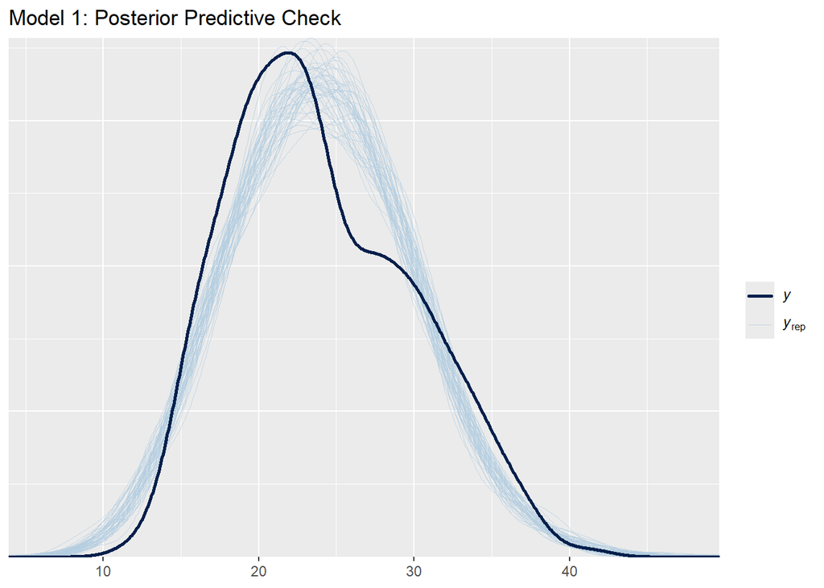

```r
pp_check(weather_model_1) +
  labs(title = "Model 1: Posterior Predictive Check")
```

# Model 2: S Kategorickym Prediktorom (raintoday)

## Specifikacia Modelu 2

$$\begin{aligned}
Y_i | \beta_0, \beta_1, \beta_2, \sigma &\stackrel{ind}{\sim}
N(\mu_i, \sigma^2) \\
\mu_i &= \beta_0 + \beta_1 \cdot \text{temp9am}_i + \beta_2 \cdot
\text{raintoday}_i
\end{aligned}$$

kde $\text{raintoday}_i = 1$ ak v den $i$ prsi, inak 0.

**Interpretacia:**

- $\beta_0$: Typicka poobednasjia teplota ked je ranna teplota 0°C a neprsi
- $\beta_1$: Zmena v poobednajsej teplote za kazdy 1°C narast rannej teploty (pri kontrole dazda)
- $\beta_2$: Rozdiel v typickej poobednajsej teplote medzi dazdivymi a bezdasdovymi dnami (pri kontrole rannej teploty)

## Simulacia Posterioru

```r
weather_model_2 <- stan_glm(
  temp3pm ~ temp9am + raintoday,
  data = weather_perth, family = gaussian,
  prior_intercept = normal(25, 5),
  prior = normal(0, 2.5, autoscale = TRUE),
  prior_aux = exponential(1, autoscale = TRUE),
  chains = 4, iter = 5000*2, seed = 84735,
  refresh = 0)
```

## Prior Specifikacia

```r
prior_summary(weather_model_2)
```

```
## Priors for model 'weather_model_2'
## ------
## Intercept (after predictors centered)
##  ~ normal(location = 25, scale = 5)
##
## Coefficients
##   Specified prior:
##     ~ normal(location = [0,0], scale = [2.5,2.5])
##   Adjusted prior:
##     ~ normal(location = [0,0], scale = [ 2.78,37.59])
##
## Auxiliary (sigma)
##   Specified prior:
##     ~ exponential(rate = 1)
##   Adjusted prior:
##     ~ exponential(rate = 0.17)
## ------
## See help('prior_summary.stanreg') for more details
```

## MCMC Diagnostika

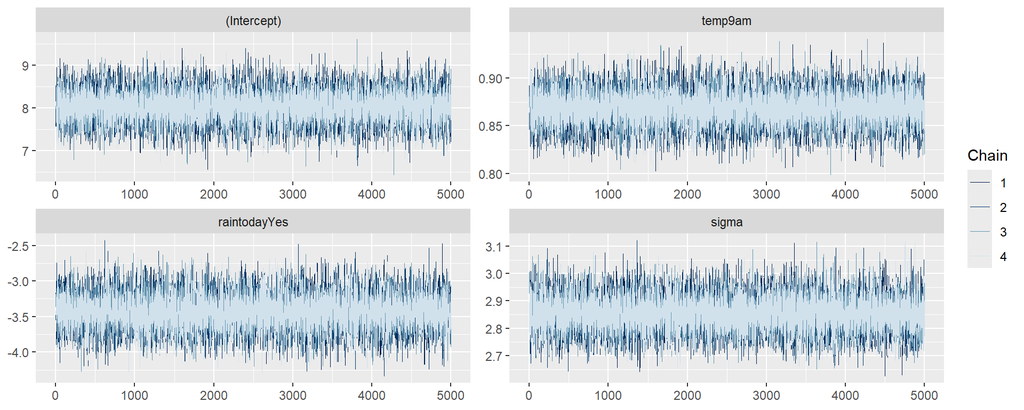

```r
mcmc_trace(weather_model_2, size = 0.1)
```

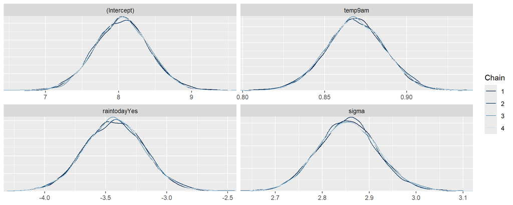

```r
mcmc_dens_overlay(weather_model_2)
```

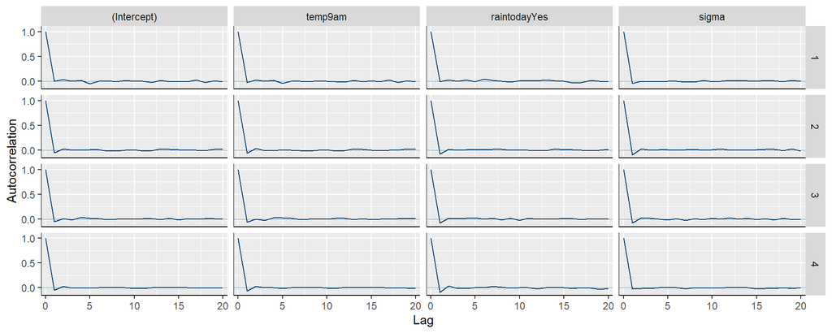

```r
mcmc_acf(weather_model_2)
```

```r
cat("Effective Sample Size Ratios:\n")
```

```
## Effective Sample Size Ratios:
```

```r
neff_ratio(weather_model_2)
```

```
##  (Intercept)      temp9am raintodayYes        sigma
##      1.05540      1.09515      1.03450      1.12040
```

```r
cat("\nR-hat hodnoty:\n")
```

```
##
## R-hat hodnoty:
```

```r
rhat(weather_model_2)
```

```
##  (Intercept)      temp9am raintodayYes        sigma
##     1.000036     1.000030     1.000074     1.000164
```

## Posterior Credible Intervals

```r
posterior_interval(weather_model_2, prob = 0.80)
```

```
##                     10%        90%
## (Intercept)   7.5721473  8.5157190
## temp9am       0.8459168  0.8917768
## raintodayYes -3.7386003 -3.1188604
## sigma         2.7729991  2.9372204
```

## Posterior Predictive Check

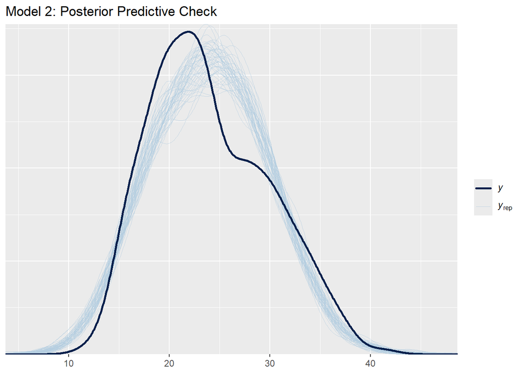

```r
pp_check(weather_model_2) +
  labs(title = "Model 2: Posterior Predictive Check")
```

# Model 3: S Interakcnym Clenom

## Specifikacia Modelu 3

$$\begin{aligned}
Y_i | \beta_0, \beta_1, \beta_2, \beta_3, \sigma
&\stackrel{ind}{\sim} N(\mu_i, \sigma^2) \\
\mu_i &= \beta_0 + \beta_1 \cdot \text{temp9am}_i + \beta_2 \cdot
\text{raintoday}_i + \beta_3 \cdot \text{temp9am}_i \cdot
\text{raintoday}_i
\end{aligned}$$

**Rozklad podla scenara:**

- **Ked neprsi** ($\text{raintoday} = 0$):
  $$\mu = \beta_0 + \beta_1 \cdot
  \text{temp9am}$$
- **Ked prsi** ($\text{raintoday} = 1$):
  $$\mu = (\beta_0 + \beta_2) + (\beta_1 + \beta_3)
  \cdot \text{temp9am}$$

**Interpretacia $\beta_3$:** Rozdiel v sklonoch - o kolko sa meni vztah medzi rannou a poobednajsiou teplotou v dazdivych dnoch oproti bezdasdovym.

## Simulacia Posterioru

```r
weather_model_3 <- stan_glm(
  temp3pm ~ temp9am + raintoday + raintoday:temp9am,
  data = weather_perth, family = gaussian,
  prior_intercept = normal(25, 5),
  prior = normal(0, 2.5, autoscale = TRUE),
  prior_aux = exponential(1, autoscale = TRUE),
  chains = 4, iter = 5000*2, seed = 84735,
  refresh = 0)
```

## Prior Specifikacia

```r
prior_summary(weather_model_3)
```

```
## Priors for model 'weather_model_3'
## ------
## Intercept (after predictors centered)
##  ~ normal(location = 25, scale = 5)
##
## Coefficients
##   Specified prior:
##     ~ normal(location = [0,0,0], scale = [2.5,2.5,2.5])
##   Adjusted prior:
##     ~ normal(location = [0,0,0], scale = [ 2.78,37.59, 2.28])
##
## Auxiliary (sigma)
##   Specified prior:
##     ~ exponential(rate = 1)
##   Adjusted prior:
##     ~ exponential(rate = 0.17)
## ------
## See help('prior_summary.stanreg') for more details
```

## MCMC Diagnostika

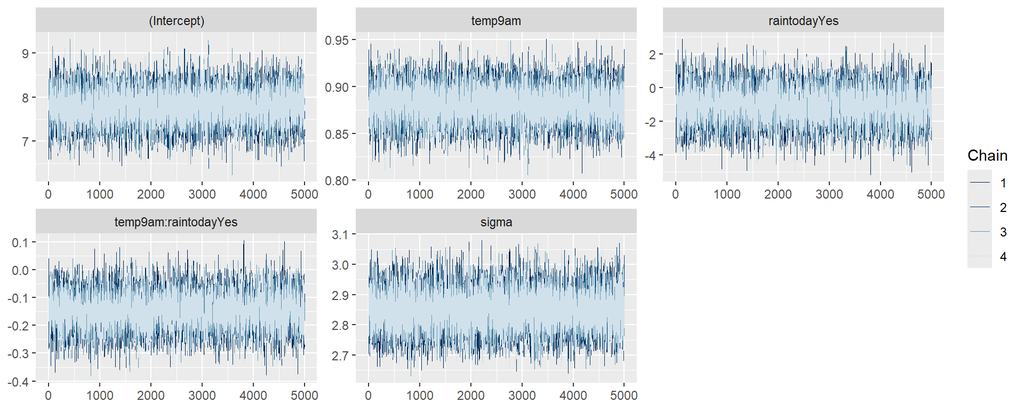

```r
mcmc_trace(weather_model_3, size = 0.1)
```

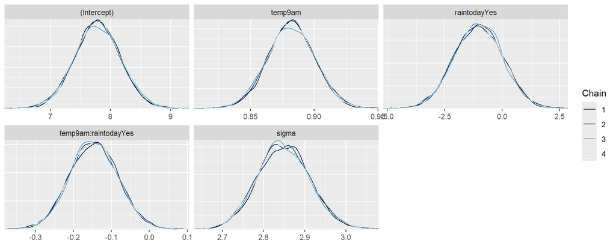

```r
mcmc_dens_overlay(weather_model_3)
```

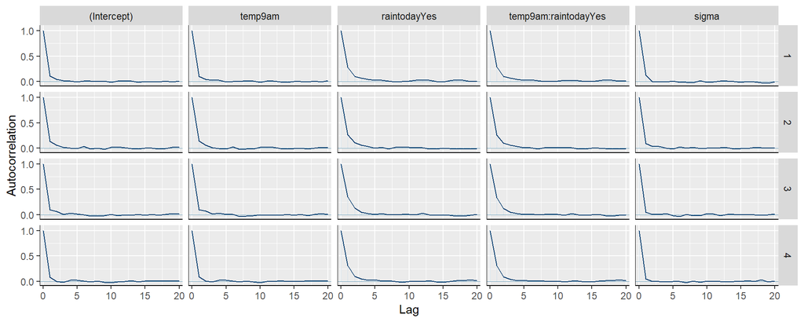

```r
mcmc_acf(weather_model_3)
```

```r
cat("Effective Sample Size Ratios:\n")
```

```
## Effective Sample Size Ratios:
```

```r
neff_ratio(weather_model_3)
```

```
##          (Intercept)              temp9am         raintodayYes
##              0.73350              0.72350              0.46880
## temp9am:raintodayYes                sigma
##              0.47455              0.83410
```

```r
cat("\nR-hat hodnoty:\n")
```

```
##
## R-hat hodnoty:
```

```r
rhat(weather_model_3)
```

```
##          (Intercept)              temp9am         raintodayYes
##            1.0000415            1.0001066            1.0000472
## temp9am:raintodayYes                sigma
##            1.0001017            0.9999276
```

## Posterior Credible Intervals

```r
posterior_interval(weather_model_3, prob = 0.80)
```

```
##                             10%         90%
## (Intercept)           7.2948958  8.27396500
## temp9am               0.8581828  0.90593202
## raintodayYes         -2.3799632  0.33276474
## temp9am:raintodayYes -0.2270746 -0.06592967
## sigma                 2.7684379  2.93133807
```

## Posterior Predictive Check

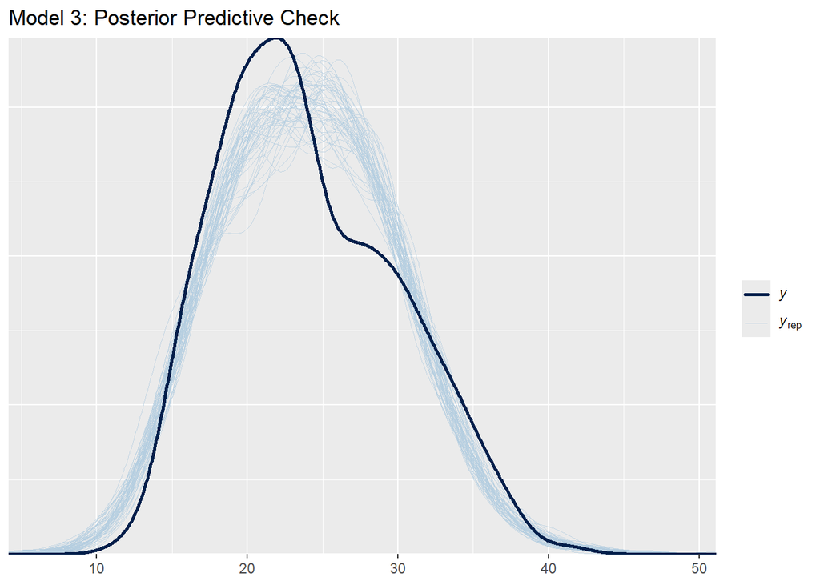

```r
pp_check(weather_model_3) +
  labs(title = "Model 3: Posterior Predictive Check")
```

## Posterior Summary

```r
tidy(weather_model_3, effects = c("fixed", "aux"),
     conf.int = TRUE, conf.level = 0.80)
```

```
## # A tibble: 6 × 5
##   term                 estimate std.error conf.low conf.high
##   <chr>                   <dbl>     <dbl>    <dbl>     <dbl>
## 1 (Intercept)             7.78     0.379     7.29     8.27
## 2 temp9am                 0.882    0.0184    0.858    0.906
## 3 raintodayYes           -1.02     1.06     -2.38     0.333
## 4 temp9am:raintodayYes   -0.147    0.0631   -0.227   -0.0659
## 5 sigma                   2.85     0.0636    2.77     2.93
## 6 mean_PPD               24.0      0.127    23.8     24.2
```

# Hodnotenie Prediktivnej Presnosti

## Vizualizacia Predikcii (Model 1)

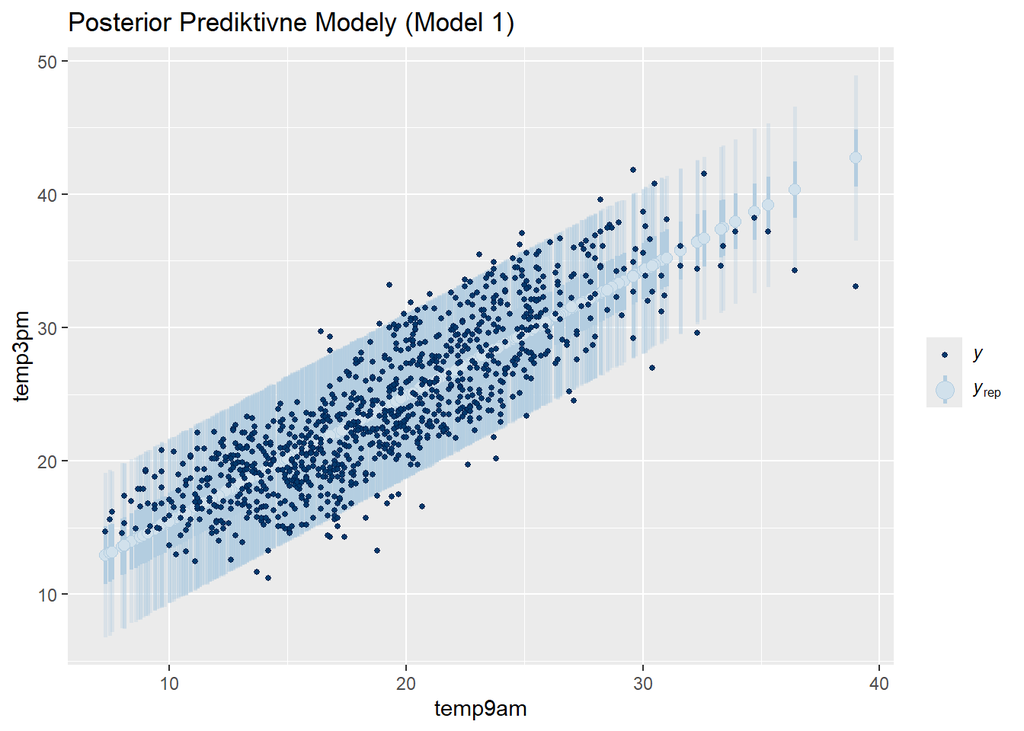

```r
set.seed(84735)
predictions_1 <- posterior_predict(weather_model_1, newdata = weather_perth)

ppc_intervals(weather_perth$temp3pm, yrep = predictions_1,
              x = weather_perth$temp9am, prob = 0.5, prob_outer = 0.95) +
  labs(x = "temp9am", y = "temp3pm",
       title = "Posterior Prediktivne Modely (Model 1)")
```

## Cross-Validation (10-fold)

```r
set.seed(84735)
cv_results <- prediction_summary_cv(model = weather_model_1, data = weather_perth, k = 10)
cv_results
```

```
## $folds
##    fold      mae mae_scaled within_50 within_95
## 1     1 2.228948  0.7175256      0.48      0.92
## 2     2 2.201198  0.6970220      0.50      0.98
## 3     3 2.365065  0.7543801      0.47      0.95
## 4     4 2.183781  0.6952262      0.48      0.97
## 5     5 2.060925  0.6503158      0.53      0.99
## 6     6 2.014212  0.6429516      0.51      0.96
## 7     7 2.389610  0.7600517      0.44      0.97
## 8     8 2.510883  0.8142646      0.44      0.92
## 9     9 2.407694  0.7693420      0.41      0.96
## 10   10 2.179479  0.7030190      0.48      0.95
##
## $cv
##        mae mae_scaled within_50 within_95
## 1 2.254179  0.7204099     0.474     0.957
```

# Porovnanie Modelov pomocou ELPD

## Vypocet ELPD

ELPD (Expected Log Predictive Density) meria ocakavanu logaritmicku prediktivnu hustotu. Vyssie hodnoty znamenaju lepsiu prediktivnu presnost.

$$\text{ELPD} = \sum_{i=1}^{n} \log p(y_i | y_{-i})$$

kde $p(y_i | y_{-i})$ je leave-one-out prediktivna hustota.

```r
set.seed(84735)
loo_1 <- loo(weather_model_1)
loo_2 <- loo(weather_model_2)
loo_3 <- loo(weather_model_3)
```

### ELPD hodnoty

**Model 1 (temp9am):** -2559.9432896 **Model 2 (temp9am + raintoday):** -2469.4435772 **Model 3 (s interakciou):** -2467.6980695

## Porovnanie Modelov

```r
loo_compare(loo_1, loo_2, loo_3)
```

```
##                 elpd_diff se_diff
## weather_model_3   0.0       0.0
## weather_model_2  -1.7       2.2
## weather_model_1 -92.2      12.0
```

## Interpretacia Porovnania

Funkcia `loo_compare()` zoradi modely od najlepsieho po najhorsi (podla ELPD):

- **elpd_diff**: Rozdiel v ELPD oproti najlepsiemu modelu (0 = najlepsi)
- **se_diff**: Standardna chyba rozdielu

**Pravidlo:** Ak $|elpd_{diff}| < 2 \times se_{diff}$, rozdiel medzi modelmi nie je statisticky vyznamny.

# Zaver

## Suhrn Modelov

| Model | Formula | Popis |
| --- | --- | --- |
| Model 1 | `temp3pm ~ temp9am` | Jednoduchy linearny model |
| Model 2 | `temp3pm ~ temp9am + raintoday` | S kategorickym prediktorom |
| Model 3 | `temp3pm ~ temp9am + raintoday + temp9am:raintoday` | S interakciou |

## Vyber Modelu

Na zaklade ELPD porovnania a principu **parsimonie** (jednoduchosti) mozeme vybrat najvhodnejsi model. Pri vybere zvazujeme:

1. **Prediktivna presnost** (ELPD)
2. **Zlozitost modelu** (pocet parametrov)
3. **Interpretovatelnost**
4. **Bias-variance trade-off**

## Posteriorny Median Model (Model 3)

Ak je Model 3 najlepsi, posteriorny median model ma tvar:

**Pre bezdasdove dni:**
$$\widehat{\text{temp3pm}} = \hat{\beta}_0 +
\hat{\beta}_1 \cdot \text{temp9am}$$

**Pre dazdive dni:**
$$\widehat{\text{temp3pm}} = (\hat{\beta}_0 +
\hat{\beta}_2) + (\hat{\beta}_1 + \hat{\beta}_3) \cdot
\text{temp9am}$$

```r
coefs <- tidy(weather_model_3)$estimate
cat("Bezdasdove dni: temp3pm =", round(coefs[1], 2), "+", round(coefs[2], 3), "* temp9am\n")
```

```
## Bezdasdove dni: temp3pm = 7.78 + 0.882 * temp9am
```

```r
cat("Dazdive dni: temp3pm =", round(coefs[1] + coefs[3], 2), "+",
    round(coefs[2] + coefs[4], 3), "* temp9am\n")
```

```
## Dazdive dni: temp3pm = 6.76 + 0.735 * temp9am
```